# Forecasting new registered companies

Testing how ARIMA-model would fit to predict new registered compies in Finland.

Data is from Tilastokeskus (www.stat.fi) and used for learning purposes.

```python
import pandas as pd
import matplotlib.pyplot as plt
```

```python
df = pd.read_csv('yritystapahtumat.csv', index_col='Vuosineljännes', delimiter='\t', header=1, parse_dates=[0])
```

```python
df['vuosi'] = df['Vuosineljännes'].str[:4]
df['q'] = df['Vuosineljännes'].str[4:]
df['date'] = pd.to_datetime(df['Vuosineljännes'])
```

```python
# creting the training set
dfset = df['Aloittaneet yritykset (lkm)'][:-2]
```

```python
# change name and data type
dfset = df.rename(columns={'Aloittaneet yritykset (lkm)':'aloittaneet'})
dfset = dfset['aloittaneet'][:-2].astype(int)
```

```python
# split to train and test
train = dfset[:18].values
test = dfset[18:].values
```

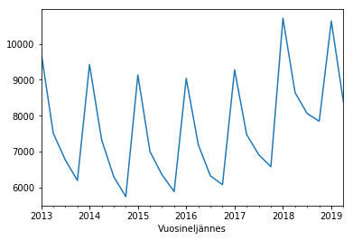

```python
dfset.plot()
```

```python
from statsmodels.graphics.tsaplots import plot_acf
```

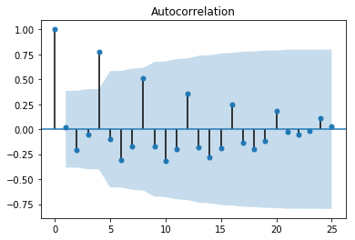

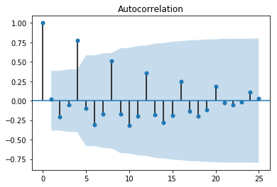

```python
plot_acf(dfset)
```

```python
from statsmodels.tsa.arima_model import ARIMA
# parameters for ARIMA-model
model_arima = ARIMA(train, order=(9,2,1))
model_arima_fit = model_arima.fit()

# validating with AIC
print(model_arima_fit.aic)
```

```
250.1964774499944
```

```python
import itertools
import warnings
warnings.filterwarnings('ignore')
p=d=q=range(0,10)
pdq = list(itertools.product(p, d, q))
bestvalue = 99999
bestcombo = ()
for param in pdq:
    try:
        model_arima = ARIMA(train, order=param)
        model_arima_fit = model_arima.fit()
        print(param, model_arima_fit.aic)
        if model_arima_fit.aic < bestvalue:
            bestvalue = model_arima_fit.aic
            bestcombo = param
    except:
        continue
print('Best combo:', bestcombo, '\n', 'Best value: ', bestvalue)
```

```
(0, 0, 0) 313.7311758137804
(0, 0, 1) 309.5896366683673
(0, 0, 2) 311.0007278778016
(0, 1, 0) 310.26766466820516
(0, 1, 1) 302.11960438624646
(0, 1, 2) 300.0655551980901
(0, 2, 0) 308.4262901491426
(0, 2, 1) 297.75672634851225
(0, 2, 2) 291.4084100519323
(1, 0, 0) 315.2128539296072
(1, 0, 1) 311.45329990718994
(1, 1, 0) 309.8959341958896
(1, 1, 8) 300.3393406395488
(1, 2, 0) 304.54952494918103
(2, 0, 0) 311.32978140419544
(2, 0, 1) 308.9362861559481
(2, 1, 0) 309.4325051756788
(2, 2, 0) 305.54973253194294
(2, 2, 1) 297.98685365323746
(3, 0, 0) 296.46507529011046
(4, 0, 0) 304.7675444626282
(6, 1, 8) 303.8823593594144
(8, 2, 2) 264.9170745557409
(8, 2, 4) 250.85893356657726
(9, 2, 1) 250.1964774499944
(9, 2, 2) 251.27803346629042
(9, 2, 3) 255.01525447907733
(9, 2, 5) 253.63497070646906
Best combo: (9, 2, 1)
 Best value:  250.1964774499944
```

```python
bestcombo
```

```
(9, 2, 1)
```

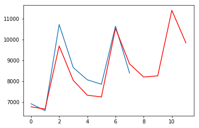

```python
predictions = model_arima_fit.forecast(steps=12)[0]
plt.plot(test)
plt.plot(predictions, color='red')
```

Overfitting anyone? Might be, but the best way the see that is to see what the numbers are going to be in the future. We have the modelled predictions for next quarters so we'll see.

```python
dfset
```

```
Vuosineljännes
2013-01-01     9767
2013-04-01     7510
2013-07-01     6763
2013-10-01     6191
2014-01-01     9425
2014-04-01     7330
2014-07-01     6300
2014-10-01     5740
2015-01-01     9137
2015-04-01     6998
2015-07-01     6349
2015-10-01     5880
2016-01-01     9037
2016-04-01     7185
2016-07-01     6319
2016-10-01     6074
2017-01-01     9278
2017-04-01     7469
2017-07-01     6910
2017-10-01     6575
2018-01-01    10718
2018-04-01     8645
2018-07-01     8059
2018-10-01     7846
2019-01-01    10637
2019-04-01     8381
Name: aloittaneet, dtype: int32
```

```python
import numpy as np
preds = pd.DataFrame(np.floor(predictions[-4:]), columns=['aloittavat'], index=['2019Q3','2019Q4','2020Q1','2019Q2'])
```

```python
preds
```

[output not shown]

Now we have our predictions for starting companies for next four quarters. There seems to be slight shits on the time series in the last couple of years which might make it more difficult to predict. Predictions are created using historic data which should be understood as looking at the numbers.

There seems to be certain pattern that highest number of new company registrations are made in the first quarter and next three quarter decreases. This might have to do with the availability of the funding for startups or simply timing of the registration. Keeping that in mind there might be interesting other independent variables that could affect the amount also.